# Class 08

DATA1220-55, Fall 2024

Sarah E. Grabinski

2024-09-16

## Homework 2

- Describing numerical distributions: modality, skew, outliers
- Describing numerical distributions: appropriate summary statistics
- Matching numerical distributions to their summary statistics, reading a boxplot
- Calculating proportions from a contingency table

## Homework 2

- [Instructions](https://canvas.jcu.edu/files/3708401/download?download_frd=1) (`homework2_instructions.pdf`), a [Quarto markdown template](https://canvas.jcu.edu/files/3708307/download?download_frd=1) (`homework2_template.qmd`), and an [example HTML output](https://canvas.jcu.edu/files/3708306/download?download_frd=1) (`homework2_example.html`) are available for download under Chapter 2 on the [Modules](https://canvas.jcu.edu/courses/36290/modules) page in Canvas.
- Upload *TWO* (2) documents to [Homework 2](https://canvas.jcu.edu/courses/36290/assignments/451733) on the [Assignments](https://canvas.jcu.edu/courses/36290/assignments) page in Canvas by *Friday 9/20/2024* by *6:00pm*: `homework2_yourlastname.qmd` and `homework2_yourlastname.html`
- [Video walk-through](https://canvas.jcu.edu/files/3708369/download?download_frd=1) of Homework 2 under Tutorials on the [Modules](https://canvas.jcu.edu/courses/36290/modules) page in Canvas. Make sure you’re caught up on the [video walk-through of homework 1](https://canvas.jcu.edu/files/3695568/download?download_frd=1).

## Late Policy

“This homework is due by 6:00pm on Friday, 9/20/24. No credit will be lost for assignments received by 7:00pm to account for issues with uploading. 10% of the points will be deducted from assignments received by 9:00am on Saturday, 9/21/24. Assignments turned in after this point are only eligible for 50% credit, so it benefits you to turn in whatever you have completed by the due date.”

## Last Time…

- Contingency tables: counts and proportions (frequencies)
- Visualizing frequencies: bar plots, mosaic plots
- Describing numerical relationships: linear vs nonlinear, strong vs weak
- Visualizing 3+ variables

## Chapter 3 Objectives

- Define probability, random processes, and the law of large numbers
- Describe the sample space for disjoint and non-disjoint outcomes
- Calculate probabilities using the General Addition and Multiplication Rules
- Create a probability distribution for disjoint outcomes

## Defining Probability

What does the word *probability* mean to you?

*“Highly likely”*

*“Probably”*

*“About even”*

*“Almost no chance”*

## People interpret probability differently

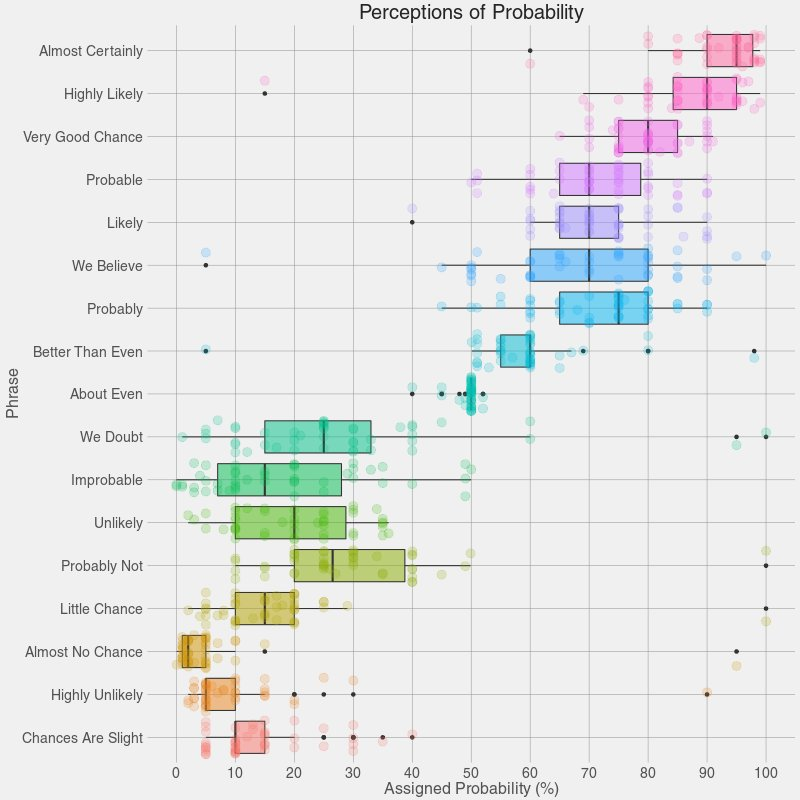

Did your estimate fall within these ranges? Are these ranges reasonable?

## So what is probability?

**Frequentist Definition**

The proportion of times that a particular outcome would occur if we observed a random process an infinite number of times.

- A *random process* is one where you know which outcomes are possible (i.e. the *sample space*) but you don’t know which outcome comes next
- Examples of a *random process*: coin toss, die roll, stock market

DATA1220-55 Fall 2024, Class 08 | Updated: 2024-09-16 | [Canvas](https://canvas.jcu.edu/courses/36290) | [Campuswire](https://campuswire.com/c/G6427C531/feed)